# R Notebook

```r
library(ggplot2)
library(CodeClanData)
library(CodeClanData)
library(tidyverse)
library(ggthemes)
library(viridis)
```

COMPARISON

Create a suitable plot for the following three datasets:

```r
late_deliveries
```

| date | late_deliveries |
| --- | --- |
| 2015-01-01 | 113 |
| 2015-02-01 | 147 |
| 2015-03-01 | 105 |
| 2015-04-01 | 146 |
| 2015-05-01 | 128 |
| 2015-06-01 | 121 |
| 2015-07-01 | 110 |
| 2015-08-01 | 128 |
| 2015-09-01 | 139 |
| 2015-10-01 | 108 |

[output cut: 38 more lines]

Late Deliveries

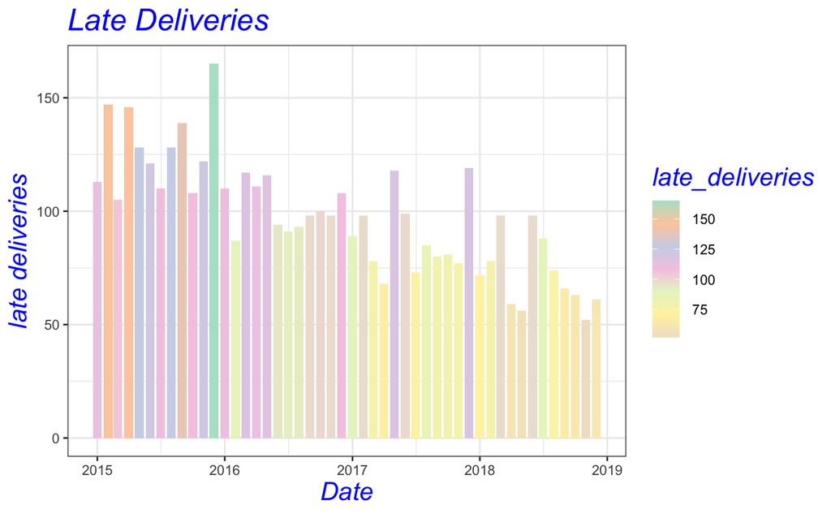

```r
ggplot(late_deliveries) +
 aes(x = date, y = late_deliveries, fill = late_deliveries, bins = 20) +
  geom_col(position = "dodge") +
  scale_fill_distiller(palette = "Pastel2") +
  theme_bw() +
  labs(
    x = "Date",
    y = "late deliveries",
    title = "Late Deliveries"
  ) +
  theme(title = element_text(size = 16, face = "italic", colour = "Blue"))
```

solution 2

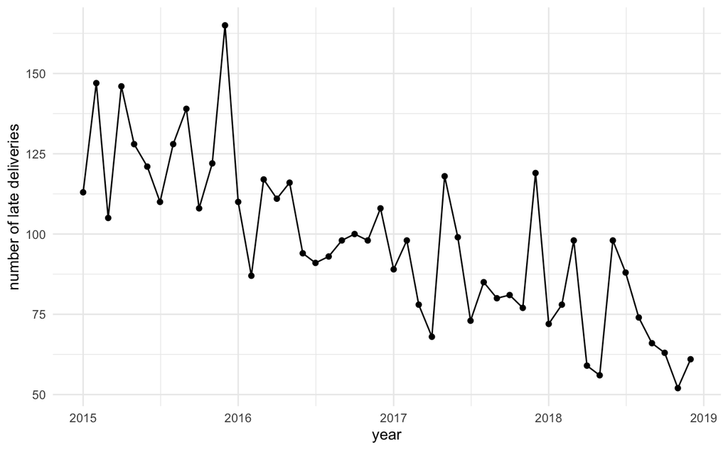

```r
ggplot(late_deliveries) +
  aes(x = date, y = late_deliveries) +
  geom_line() +
  geom_point() +
  labs(x = "year", y = "number of late deliveries") +
  theme_minimal()
```

Recovery time

```r
recovery_times
```

| prognosis | treatment_group | recovery |
| --- | --- | --- |
| Excellent | treatment_a | 6 |
| Good | treatment_a | 7 |
| Average | treatment_a | 12 |
| Poor | treatment_a | 15 |
| Excellent | treatment_b | 7 |
| Good | treatment_b | 12 |
| Average | treatment_b | 13 |
| Poor | treatment_b | 17 |
| Excellent | control | 8 |
| Good | control | 16 |

[output cut: 2 more lines]

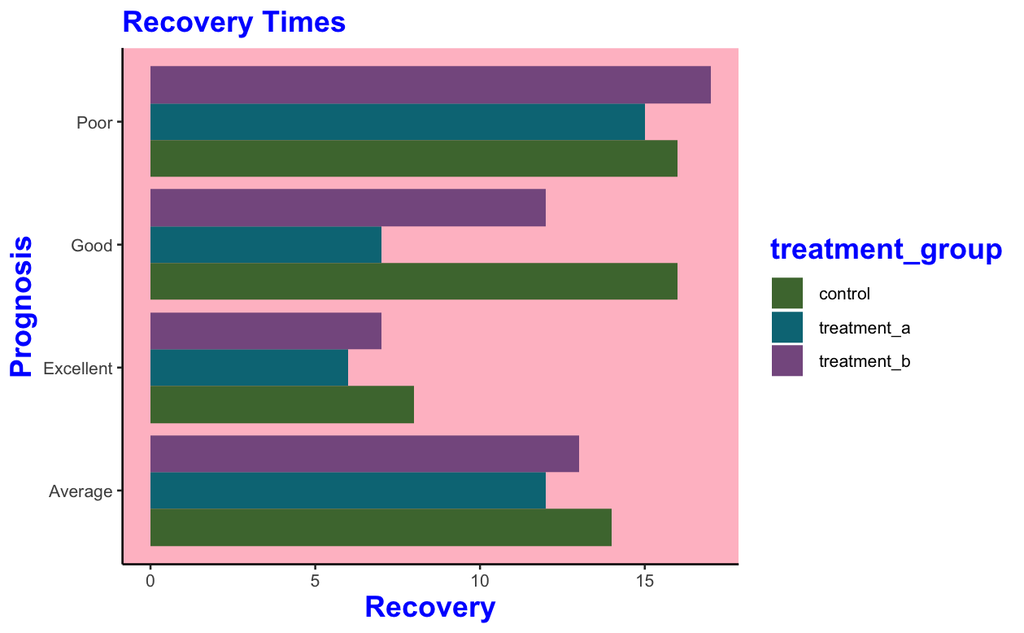

```r
ggplot(recovery_times) +
  aes(x = recovery, y = prognosis, fill = treatment_group) +
  geom_col(position = "dodge") +
  scale_fill_hue(h = c(120,300), c = 40, l = 45) +
  theme_classic(11) +
  labs(
    x = "Recovery",
    y = "Prognosis",
    title = "Recovery Times"
  ) +
  theme(
    title = element_text(size = 15, face = "bold", colour = "blue"),
    panel.background = element_rect(fill = "Pink"),
    panel.grid = element_blank(),
    plot.title = element_text(size = 15, face = "bold", colour = "blue")
  )
```

```r
NA
NA
```

solution 2

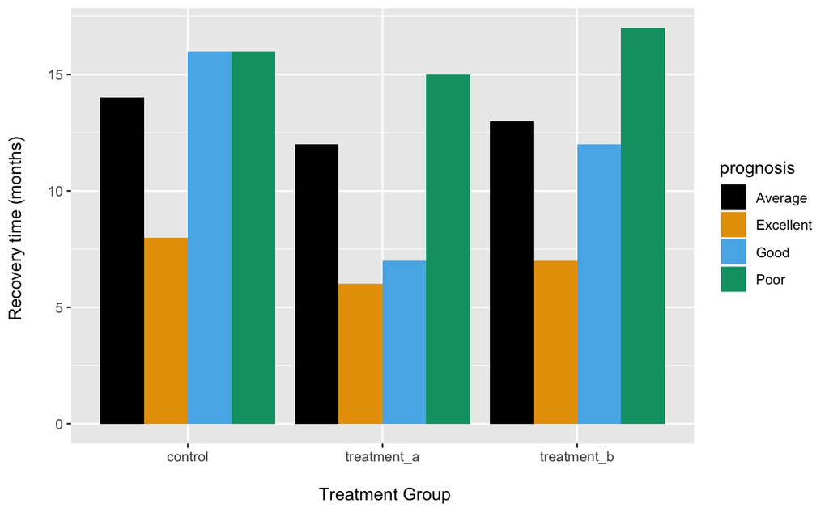

```r
ggplot(recovery_times) +
  aes(x = treatment_group, y = recovery, fill = prognosis) +
  geom_col(position = "dodge") +
  labs(x = "\n Treatment Group", y = "Recovery time (months) \n") +
    scale_fill_colorblind()
```

```r
NA
NA
```

Fitness Level

```r
fitness_levels
```

| child | group | age | fitness_score |
| --- | --- | --- | --- |
| A | 1 | 8 | -1.62330074 |
| B | 1 | 8 | 0.92921917 |
| C | 1 | 8 | -1.24225644 |
| D | 1 | 8 | -1.37327043 |
| E | 2 | 8 | 0.05959228 |
| F | 2 | 8 | 0.02355118 |
| G | 2 | 8 | 0.64069994 |
| H | 2 | 8 | 0.20409569 |
| I | 3 | 8 | -1.20721756 |
| J | 3 | 8 | -1.45389172 |

[output cut: 110 more lines]

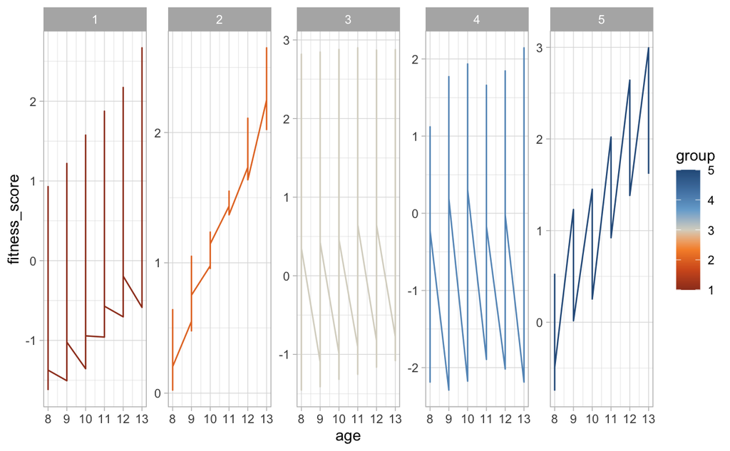

```r
ggplot(fitness_levels) +
  aes(x = age, y = fitness_score, colour = group) +
  geom_line() +
  theme_light() +
  facet_wrap(~ group, ncol = 10, scales = "free") +
  scale_color_gradient2_tableau()
```

```r
NA
NA
```

Solution 2

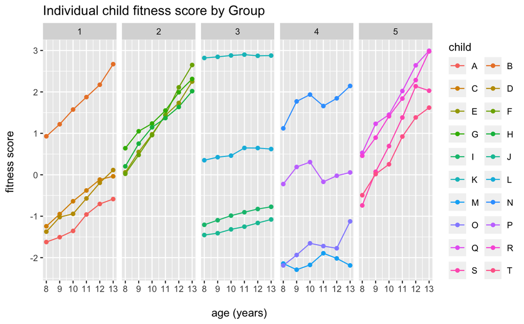

```r
ggplot(fitness_levels) +
  aes(x = age, y = fitness_score, group = child, color = child) +
  geom_line() +
  geom_point() +
  facet_wrap(~ group, ncol = 5) +
  labs(y = "fitness score \n", x = "\n age (years)", title = "Individual child fitness score by Group") +
  scale_colour_hue(guide = guide_legend(nrow = 10, byrow = TRUE))
```

CONNECTION

Blood Pressure

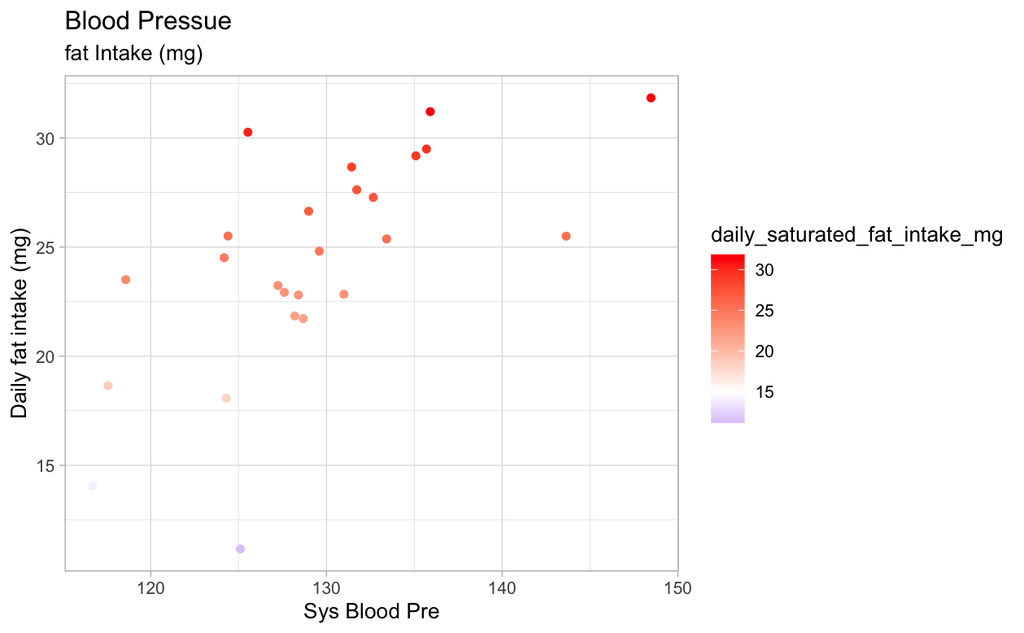

```r
ggplot(blood_pressure) +
  aes(x = systolic_blood_pressure_mm_hg, y = daily_saturated_fat_intake_mg, colour = daily_saturated_fat_intake_mg) +
  geom_point() +
  scale_colour_gradient2(low = "blue", high = "red", mid = "white", midpoint = 15) +
  labs(
    x = "Sys Blood Pre",
    y = "Daily fat intake (mg)",
    title = "Blood Pressue",
    subtitle = "fat Intake (mg)"
  ) +
  theme_light()
```

Solution 2

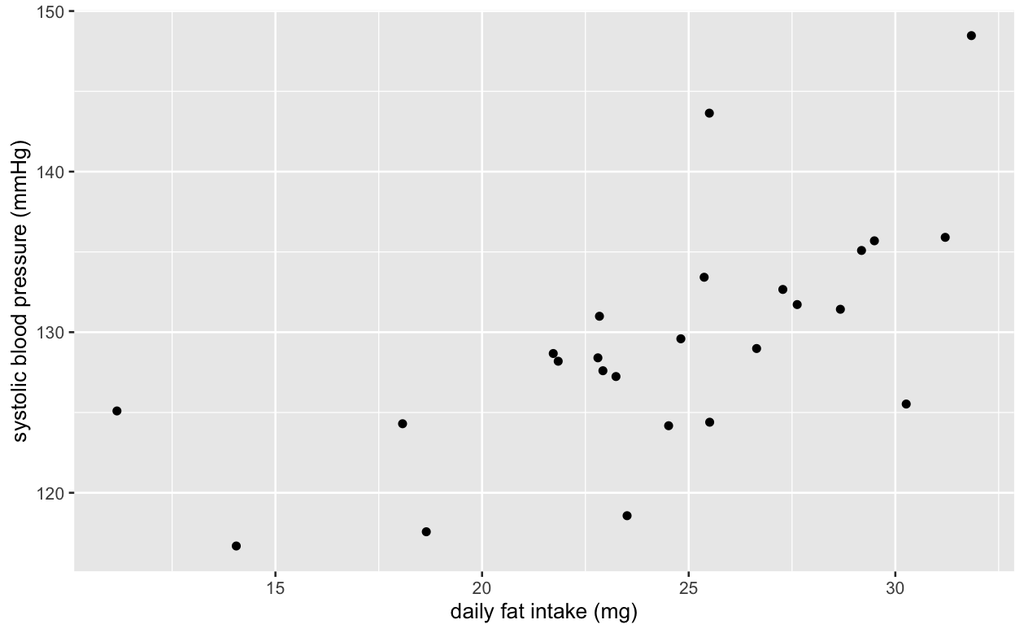

```r
ggplot(blood_pressure) +
  aes(
    x = daily_saturated_fat_intake_mg,
    y = systolic_blood_pressure_mm_hg
  ) +
  geom_point() +
  labs(x = "daily fat intake (mg)", y = "systolic blood pressure (mmHg)")
```

Car use

```r
car_use
```

| city | car_use_percent | population | air_so2_concentration_ppm |
| --- | --- | --- | --- |
| A | 0.19013438 | 52756.531 | 0.30875771 |
| B | 0.25217388 | 183568.685 | 2.05706964 |
| C | 0.33515476 | 3283.328 | 0.58613122 |
| D | 0.13688274 | 88007.259 | 0.40313389 |
| E | 0.03645527 | 35903.005 | 0.09004440 |
| F | 0.30323094 | 140839.253 | 1.35560297 |
| G | 0.14375222 | 15180.033 | 0.25132502 |
| H | 0.24954498 | 139114.661 | 1.58342865 |
| I | 0.36142508 | 103599.799 | 1.13994748 |
| J | 0.33829070 | 180702.788 | 2.10768370 |

[output cut: 22 more lines]

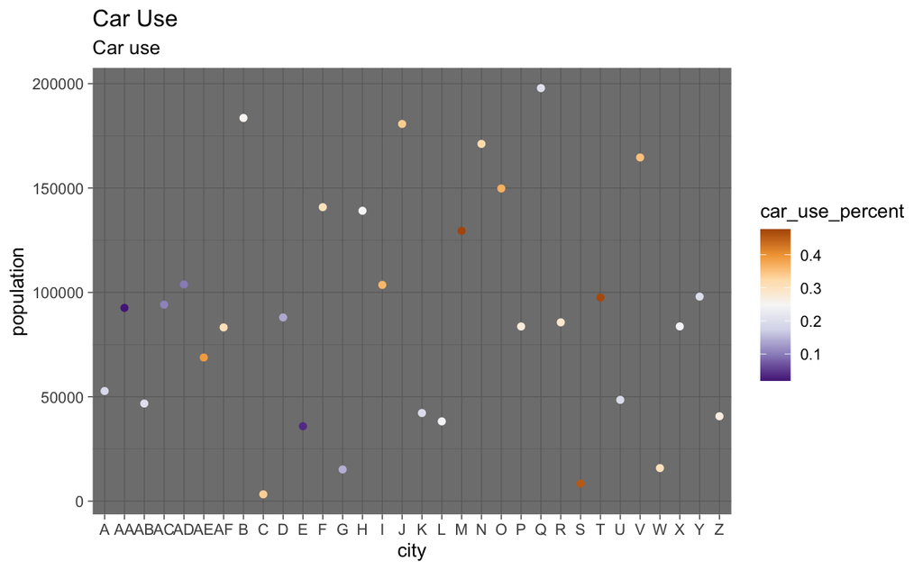

```r
ggplot(car_use) +
  aes(x = city, y = population, colour = car_use_percent) +
  geom_point() +
  scale_color_distiller(palette = "PuOr") +
  theme_dark() +
  labs(
    title = "Car Use",
    subtitle = "Car use"
  )
```

```r
NA
NA
NA
```

solution 2

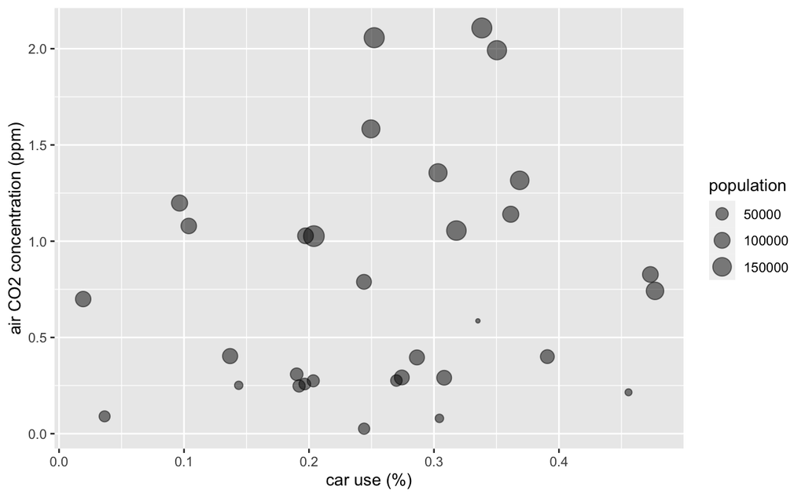

```r
ggplot(car_use) +
  aes(
    x = car_use_percent,
    y = air_so2_concentration_ppm,
    size = population
  ) +
  geom_point(alpha = 0.5) +
  labs(x = "car use (%)", y = "air CO2 concentration (ppm)")
```

DISTRIBUTION

D20 Outcome

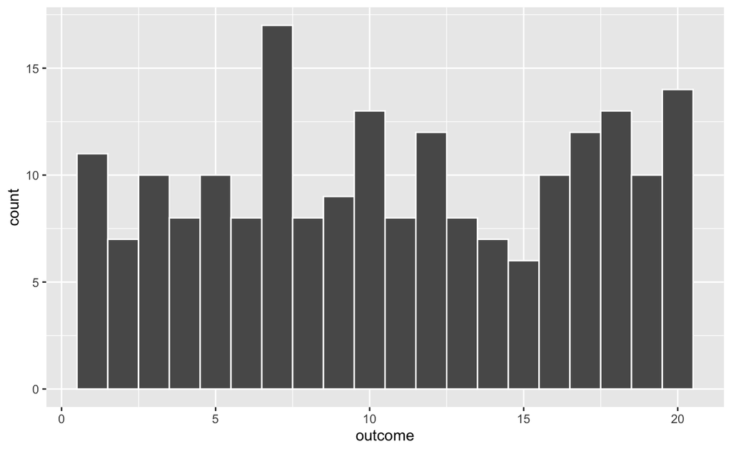

```r
ggplot(d20_outcomes) +
  aes(x = outcome) +
  geom_histogram(bins = 20, col = "white")
```

solution 2

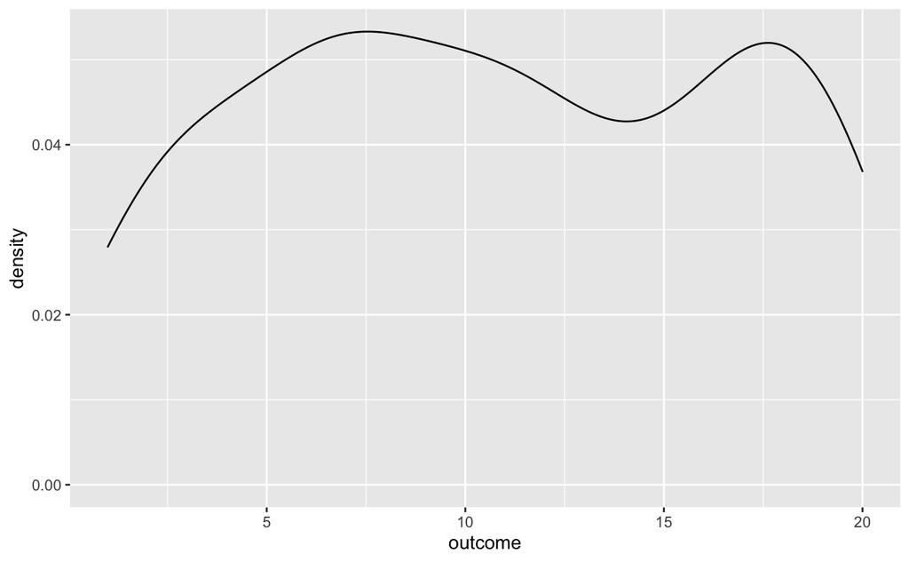

```r
ggplot(d20_outcomes) +
  aes(x = outcome) +
  geom_density()
```

COMPOSITION

Pension Surplus

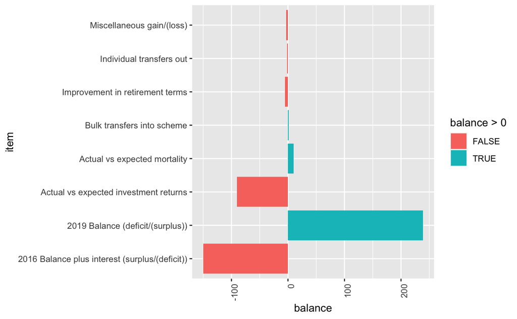

```r
ggplot(pension_surplus) +
  aes(x = item, y = balance, fill = balance > 0) +
  geom_col() +
  theme(axis.text.x = element_text(angle = 90, hjust = 1)) +
  coord_flip()
```

Pension Liabilities

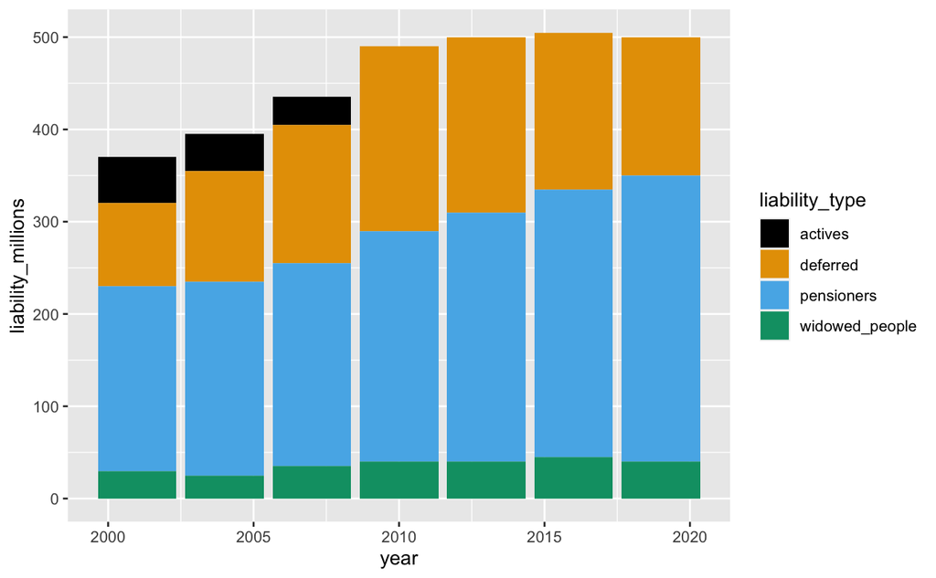

```r
ggplot(pension_liabilities) +
  aes(x = year, y = liability_millions, fill = liability_type) +
  geom_col() +
  scale_fill_colorblind()
```

Homework part 1

```r
library(ggplot2)
library(CodeClanData)
library(dplyr)
```

1. Take the data in the dataset qb_revenue_breakdown and make a stacked bar chart showing the sources of revenue across the two years in the dataset.

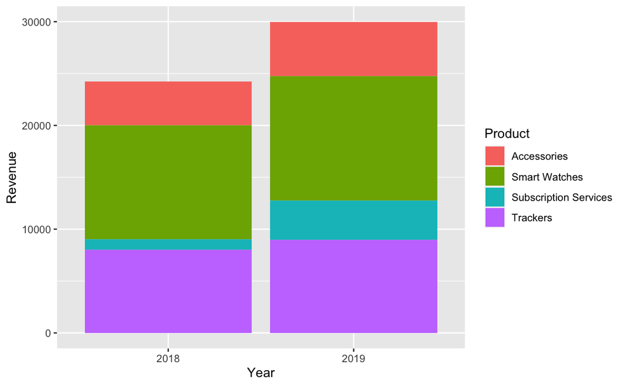

```r
ggplot(qb_revenue_breakdown) +
  aes(x = Year, y = Revenue, fill = Product) +
  geom_col()
```

2. Make a line chart showing monthly sales of the “flagship product” - the KwikBit Unit1 - over the last year. This data is inside qb_monthly_sales, but you will need to use subset.

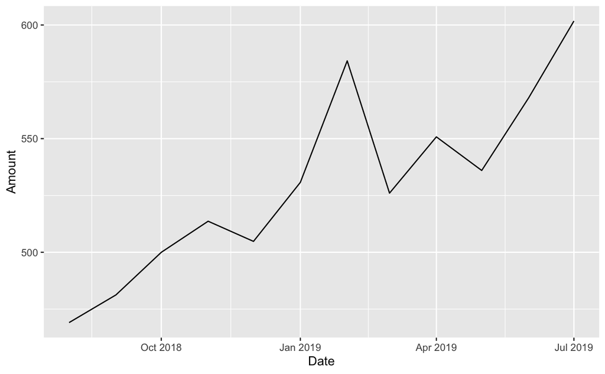

```r
kwikbit_sales <- subset(qb_monthly_sales, Cashflow == "Kwikbit Unit 1 Sales")

ggplot(kwikbit_sales) +
  aes(x = Date, y = Amount) +
  geom_line()
```

3. Make a line chart showing monthly revenue and costs over the last year. This data is also in qb_monthly_sales.

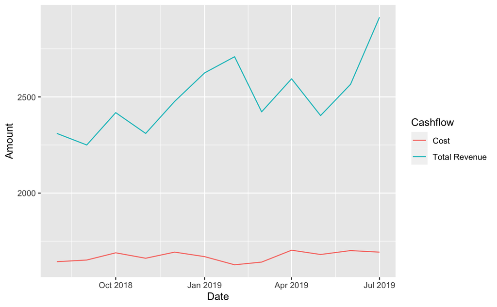

```r
revenue_and_costs <- subset(qb_monthly_sales, Cashflow != "Kwikbit Unit 1 Sales")

ggplot(revenue_and_costs) +
  aes(x = Date, y = Amount, colour = Cashflow) +
  geom_line()
```

4. Show annual sales of personal fitness trackers over the last 5 years broken down by company as a ribbon plot (use geom_area). This data is in qb_competitors.

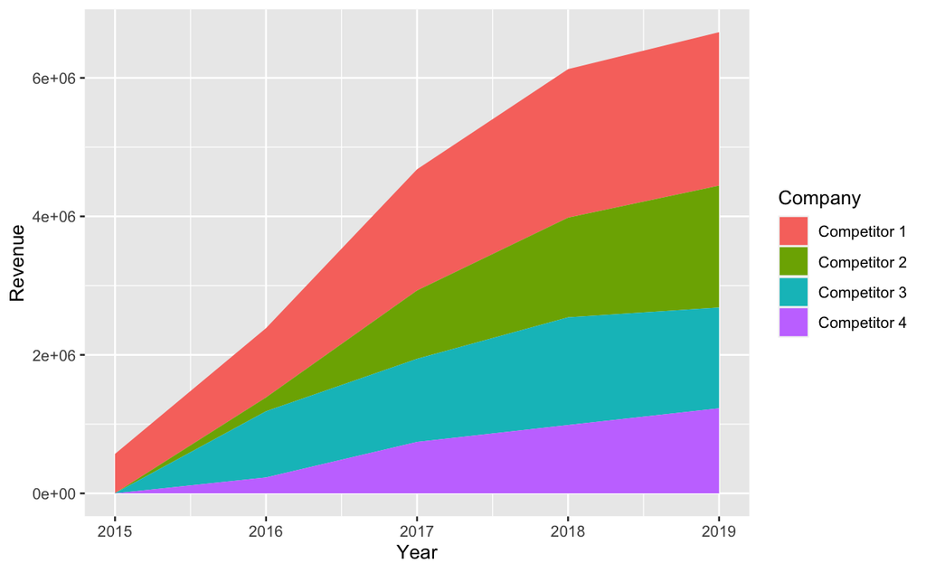

```r
ggplot(qb_competitors) +
  aes(x = Year, y = Revenue, fill = Company) +
  geom_area()
```

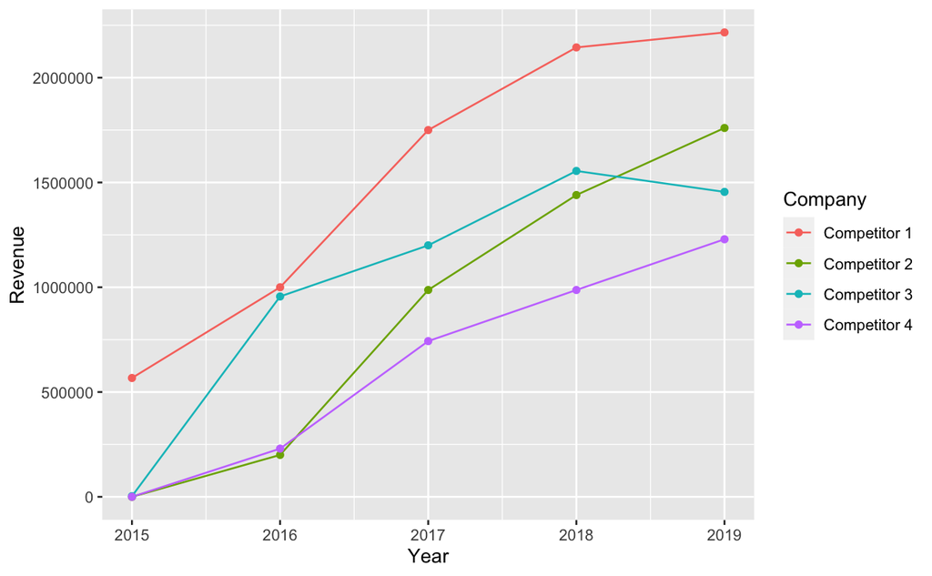

```r
ggplot(qb_competitors) +
  aes(x = Year, y = Revenue, colour = Company) +
  geom_line() +
  geom_point()
```

6. Now the company wants to compare the number of steps that their device counts vs. their competitors. Make a line graph of the number of steps throughout time, and use faceting to compare between individuals and people. Data is in qb_device_data.

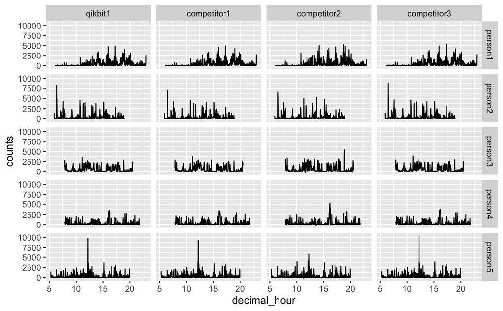

```r
qb_device_data <-
mutate(qb_device_data, decimal_hour = hours + (mins/60))

ggplot(qb_device_data) +
  aes(x = decimal_hour, y = counts) +
  geom_line() +
  facet_grid(id ~ device)
```

Take the plots that you produced in part one and now polish them by:

Adding appropriate labels Changing the scales and coordinates when appropriate. Applying a unified theme, which is described below: Graphs should have white backgrounds, and use colour sparingly. There should be faint grid lines. Font sizes should be ~12pt although titles should be slightly larger and axis labels can be slightly smaller. All plots should use colours from the following company colour scheme.

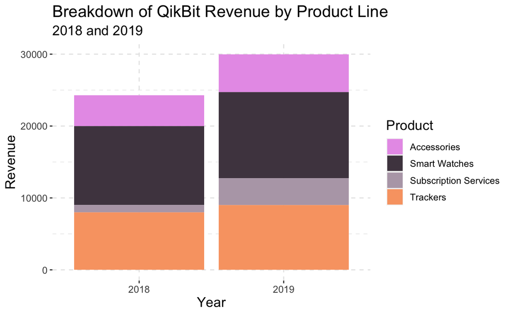

```r
col_scheme <- c("#E89FE9", "#50434F", "#B6A7B5", "#F9A472", "#BD7040")
theme_qb <-
  theme(
    text = element_text(size = 12),
    title = element_text(size = 14),
    axis.text = element_text(size = 10),
    panel.background = element_rect(fill = "white"),
    panel.grid = element_line(colour = "grey90", linetype = "dashed")
  )
ggplot(qb_revenue_breakdown) +
  aes(x = Year, y = Revenue, fill = Product) +
  geom_col() +
  scale_fill_manual(values = col_scheme) +
  ggtitle(
    "Breakdown of QikBit Revenue by Product Line",
    subtitle =  "2018 and 2019"
  ) +
  theme_qb
```

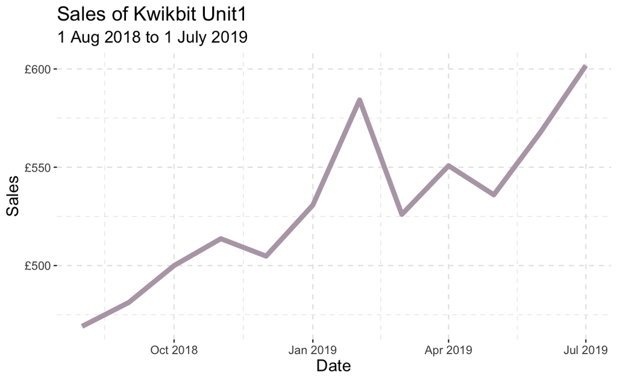

```r
kwikbit_sales <- subset(qb_monthly_sales, Cashflow == "Kwikbit Unit 1 Sales")

ggplot(kwikbit_sales) +
  aes(x = Date, y = Amount, group = Cashflow) +
  geom_line(size = 2, colour = col_scheme[3]) +
  theme_qb +
  scale_y_continuous("Sales", labels = scales::dollar_format(prefix = "£")) +
  ggtitle("Sales of Kwikbit Unit1", subtitle = "1 Aug 2018 to 1 July 2019")
```

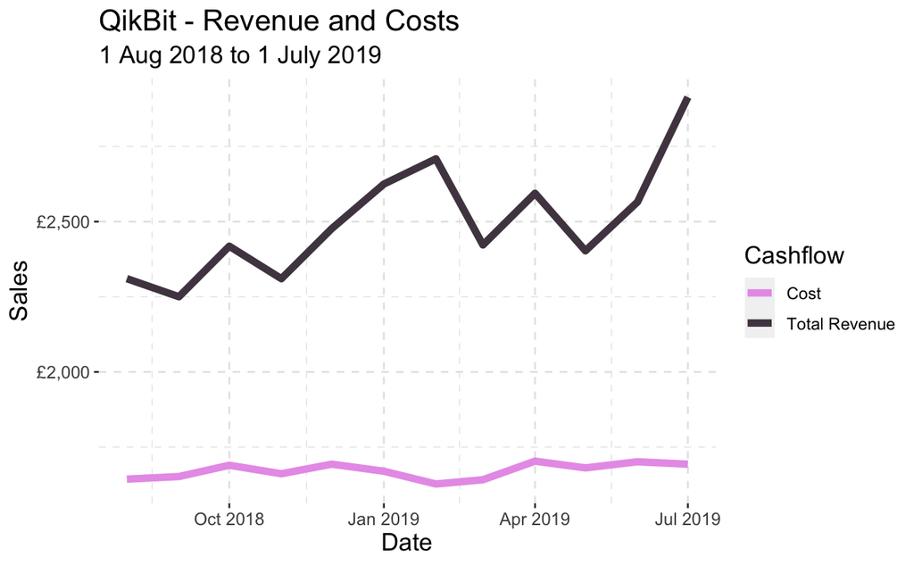

```r
revenue_and_costs <- subset(qb_monthly_sales, Cashflow != "Kwikbit Unit 1 Sales")

ggplot(revenue_and_costs) +
  aes(x = Date, y = Amount, colour = Cashflow, group = Cashflow) +
  geom_line(size = 2) +
  theme_qb +
  scale_colour_manual(values = col_scheme) +
  scale_y_continuous("Sales", labels = scales::dollar_format(prefix = "£")) +
  ggtitle("QikBit - Revenue and Costs", subtitle = "1 Aug 2018 to 1 July 2019")
```

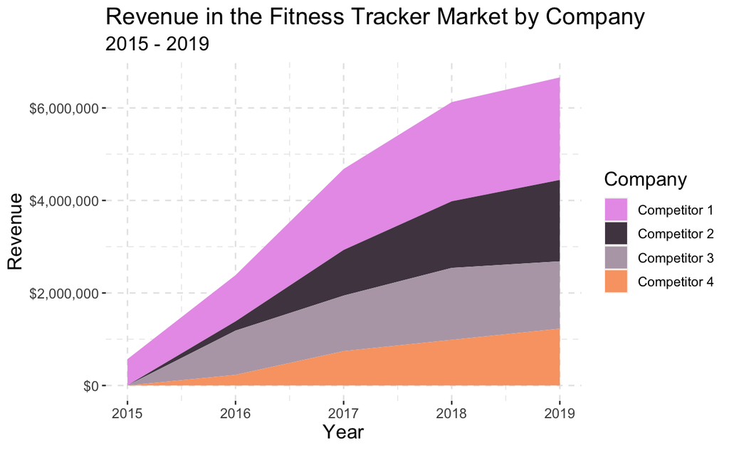

```r
ggplot(qb_competitors) +
  aes(x = Year, y = Revenue, fill = Company) +
  geom_area() +
  scale_y_continuous(labels = scales::dollar) +
  theme_qb +
  scale_fill_manual(values = col_scheme) +
  ggtitle(
    "Revenue in the Fitness Tracker Market by Company",
    subtitle = "2015 - 2019"
  )
```

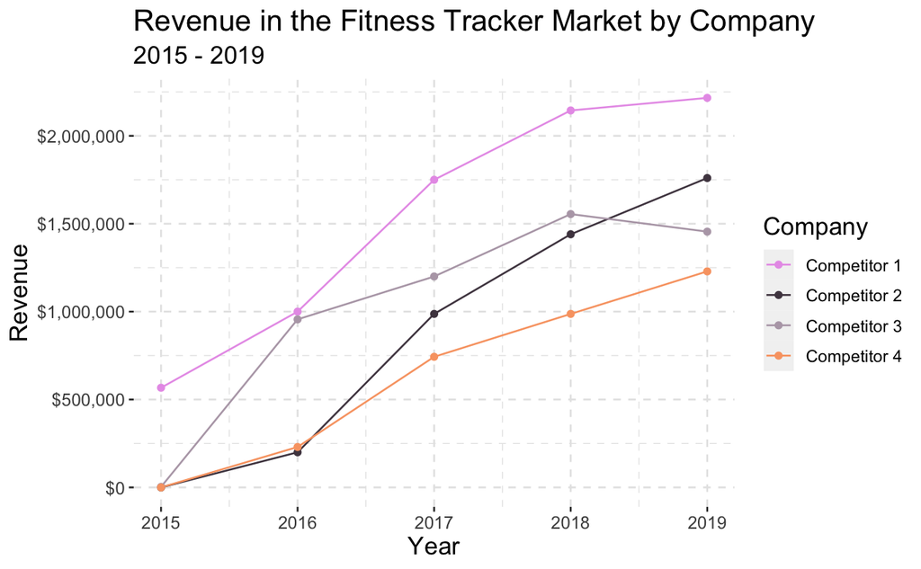

```r
ggplot(qb_competitors) +
  aes(x = Year, y = Revenue, colour = Company) +
  geom_line() +
  geom_point() +
  scale_y_continuous(labels = scales::dollar) +
  theme_qb +
  scale_colour_manual(values = col_scheme) +
  ggtitle(
    "Revenue in the Fitness Tracker Market by Company",
    subtitle = "2015 - 2019"
  )
```

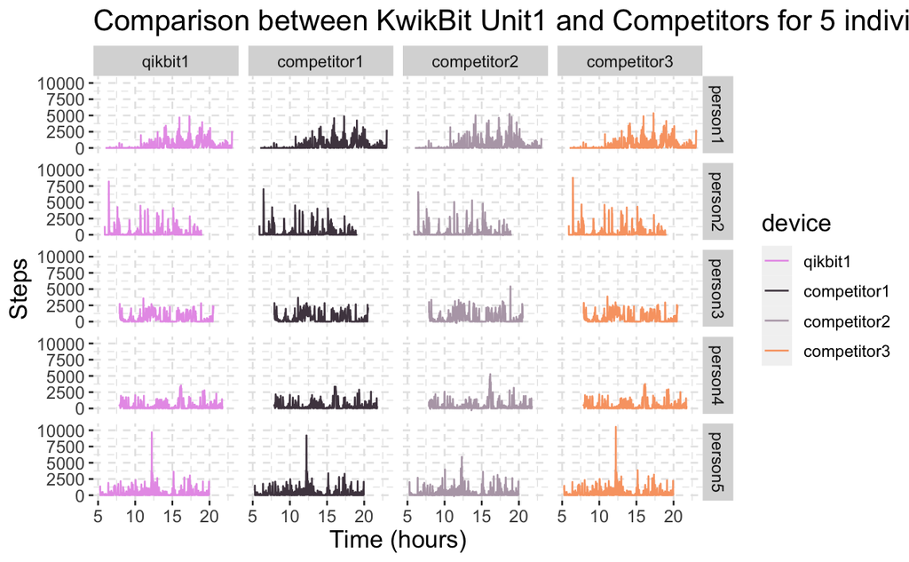

```r
ggplot(qb_device_data) +
  aes(x = decimal_hour, y = counts, colour = device) +
  geom_line() +
  scale_x_continuous("Time (hours)") +
  scale_y_continuous("Steps") +
  facet_grid(id ~ device) +
  scale_colour_manual(values = col_scheme) +
  theme_qb +
  ggtitle("Comparison between KwikBit Unit1 and Competitors for 5 individuals")
```